# Eishockey Potsdam

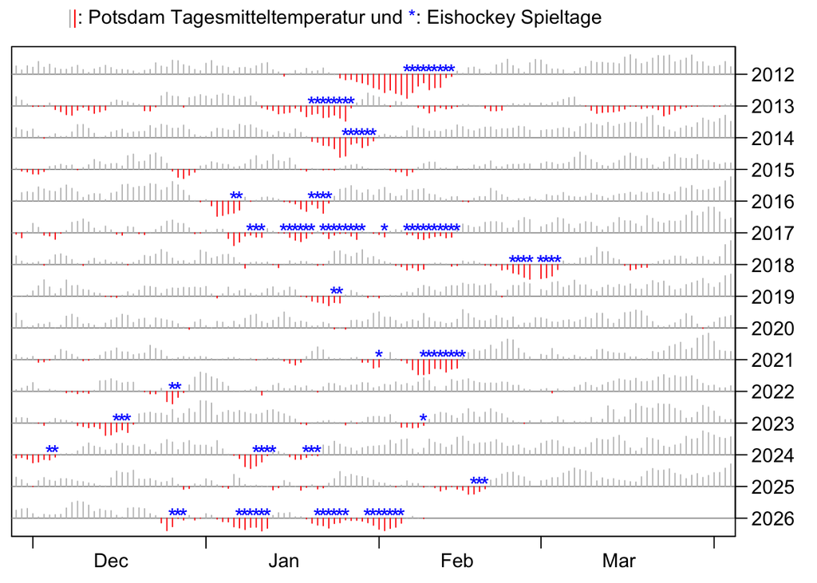

## Mitspielen

Neue Spieler sind ausdrücklich willkommen, auch ohne Ausrüstung!

Zur Absprache, wann und wo wir spielen, nutzen wir:

- [WhatsApp Gruppe für Potsdam](https://chat.whatsapp.com/Fr7jS8lyqk2HEartrjN4nJ)
- [WhatsApp Community für Brandenburg adH](https://chat.whatsapp.com/GNZhYHLWmNy90Ij2rRIrJA)
- Emailverteiler (sende Email mit Betreff subscribe an eis-list-join@uni-potsdam.de)

Wir spielen als Amateure ohne Schutzausrüstung und halten **Schläger und Puck unten**.  
In all den Jahren gab es nur eine Verletzung, die genäht werden musste - und eingebrochen sind wir nie.

## Spielorte

- [Kindermannsee](https://maps.app.goo.gl/M44R2Vkqe9215bVFA) im Park Babelsberg (hält schon früh)
- [Maschinenteich](https://maps.app.goo.gl/6kfiA2UU5YjYn7oh9) im Park Sanssouci (Parkwächter)
- [Bornstedter See](https://maps.app.goo.gl/zEiQNKmm9dEsGst78) (sehr nice)
- [Heiliger See](https://maps.app.goo.gl/hAP5ezWwnmMJtP2aA) vor dem Marmorpalais (selten zugefroren)
- [Baggersee](https://maps.app.goo.gl/FUDTQgXTaJv4HUoq6) am Stern (zukünftig mehr Nutzung, da ich da jetzt wohne)

[interactive chart not shown]

## Ausrüstung

Ich (Berry) habe immer 5 Schläger, Schneeschieber, Teamleibchen, Pucks und Tore dabei. Schläger sind oft Mangelware, also gerne auch mehrere mitbringen, wenn du hast.  
Ich habe auf Anfrage Schlittschuhe zu verleihen in den Größen 37-40 (justierbar), 38.5, 41, 42, 44.

Wer kostengünstig gebrauchte Schlittschuhe sucht, findet diese ggf. in Sozialläden wie Exvoto Bornim oder Rückenwind am Stern.

## Hintergrund

Mein Eishockey-leben begann 2012 im Kurs von Till Francke über numerische Modellierung bei der Berechnung der Eisdicke. Ich habe von meinen Erfahrungen mit Eislaufen erzählt (als Modellverifizierung) und er lud mich zum Spielen ein.  
Nach 5 Minuten war ich ein Fan fürs Leben und seitdem habe ich die Tage protokolliert, an denen wir spielen konnten.  
Die Daten der ersten Jahre (insbesondere 2012) sind nicht so vollständig wie in späteren Jahren. Mit der steigenden Anzahl von Personen in der Mailingliste waren wir immer früher draußen ^^.  
Ich habe nicht an allen Tagen selbst gespielt, sondern auch aufgezeichnet, wann andere Personen aus unserer Runde dabei waren.

Wann und wo wir in der Vergangenheit gespielt haben, ist [hier](https://github.com/brry/ice/blob/master/Eishockey_Tage.txt) gelistet *(Rechtsklick auf “Raw” -> “Ziel speichern unter”)*.  
Der R code für diese Seite (inkl. Wetterdaten und Grafik) ist [hier](https://github.com/brry/ice/blob/master/index.qmd) einsehbar.  
Alles ist unter GPL3 lizenziert (Verbreiten und Bearbeiten erwünscht, bitte diese Seite angeben).  
Feedback ist sehr willkommen als [Issue](https://github.com/brry/ice/issues) oder E-Mail.

Gut programmiert? Ich bin freiberuflich buchbar, siehe brry.github.io.

## Experimentelle Grafiken

Klimawandel:

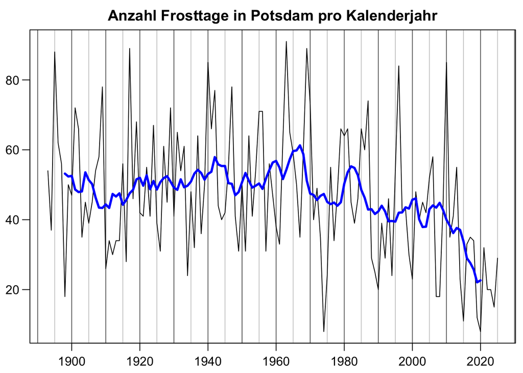

Eine größere zeitliche Auflösung der ersten Grafik ist verfügbar, aber grafisch weniger verdaulich:

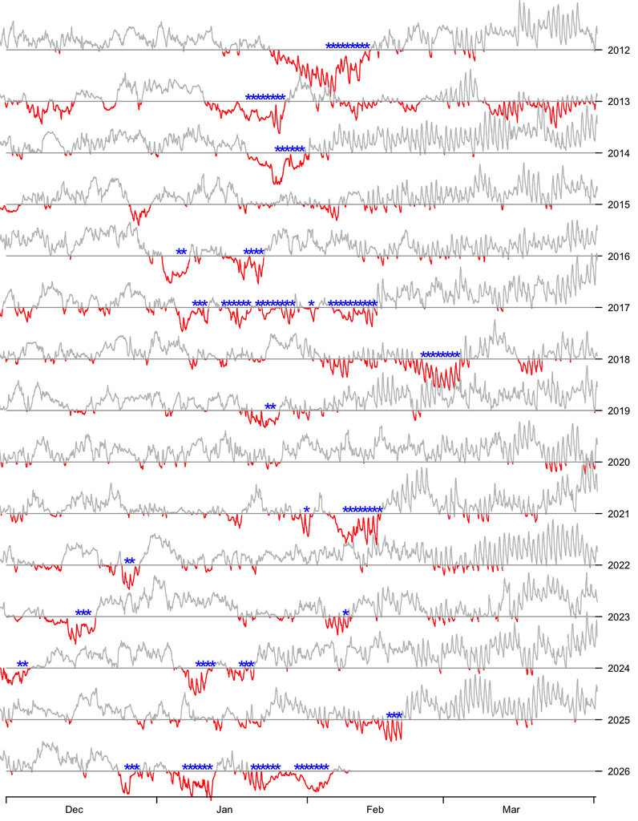